# ANCOVA in Palavras Corretas (1 Min) (Palavras Corretas (1 Min))

Geiser C. Challco geiser@alumni.usp.br

- Descriptive Statistics of Initial Data
- ANCOVA and Pairwise for one factor: **grupo**
  - Without remove non-normal data
  - Computing ANCOVA and PairWise After removing non-normal data (OK)
    - Plots for ancova
    - Checking linearity assumption
    - Checking normality and homogeneity
- ANCOVA and Pairwise for two factors **grupo:Sexo**
  - Without remove non-normal data
  - Computing ANCOVA and PairWise After removing non-normal data (OK)
    - Plots for ancova
    - Checking linearity assumption
    - Checking normality and homogeneity
- ANCOVA and Pairwise for two factors **grupo:Zona**
  - Without remove non-normal data
  - Computing ANCOVA and PairWise After removing non-normal data (OK)
    - Plots for ancova
    - Checking linearity assumption
    - Checking normality and homogeneity
- ANCOVA and Pairwise for two factors **grupo:Cor.Raca**
  - Without remove non-normal data
  - Computing ANCOVA and PairWise After removing non-normal data (OK)
    - Plots for ancova
    - Checking linearity assumption
    - Checking normality and homogeneity
- ANCOVA and Pairwise for two factors **grupo:TFL.corretas.per.min.quintile**
  - Without remove non-normal data
  - Computing ANCOVA and PairWise After removing non-normal data (OK)
    - Plots for ancova
    - Checking linearity assumption
    - Checking normality and homogeneity
- Summary of Results
  - Descriptive Statistics
  - ANCOVA Table Comparison
  - PairWise Table Comparison
  - EMMS Table Comparison

**NOTE**:

- Teste ANCOVA para determinar se houve diferenças significativas no Palavras Corretas (1 Min) (medido usando pre- e pos-testes).
- ANCOVA test to determine whether there were significant differences in Palavras Corretas (1 Min) (measured using pre- and post-tests).

# Descriptive Statistics of Initial Data

```r
df <- get.descriptives(dat, c(dv.pre, dv.pos), c("grupo"),
                       include.global = T, symmetry.test = T, normality.test = F)
df <- plyr::rbind.fill(
  df, do.call(plyr::rbind.fill, lapply(lfatores2, FUN = function(f) {
    if (nrow(dat) > 0 && sum(!is.na(unique(dat[[f]]))) > 1)
      get.descriptives(dat, c(dv.pre,dv.pos), c("grupo", f),
                       symmetry.test = T, normality.test = F)
    }))
)
(df <- df[,c(fatores1[fatores1 %in% colnames(df)],"variable",
             colnames(df)[!colnames(df) %in% c(fatores1,"variable")])])
```

```
##           grupo Sexo   Zona Cor.Raca TFL.corretas.per.min.quintile                 variable   n    mean median
## 1      Controle <NA>   <NA>     <NA>                          <NA> TFL.corretas.per.min.pre  90  90.222   92.0
## 2  Experimental <NA>   <NA>     <NA>                          <NA> TFL.corretas.per.min.pre  53  92.170   92.0
## 3          <NA> <NA>   <NA>     <NA>                          <NA> TFL.corretas.per.min.pre 143  90.944   92.0
## 4      Controle <NA>   <NA>     <NA>                          <NA> TFL.corretas.per.min.pos  90 113.022  113.0
## 5  Experimental <NA>   <NA>     <NA>                          <NA> TFL.corretas.per.min.pos  53 113.660  111.0
## 6          <NA> <NA>   <NA>     <NA>                          <NA> TFL.corretas.per.min.pos 143 113.259  112.0
## 7      Controle    F   <NA>     <NA>                          <NA> TFL.corretas.per.min.pre  36  92.333   95.5
## 8      Controle    M   <NA>     <NA>                          <NA> TFL.corretas.per.min.pre  54  88.815   89.0
## 9  Experimental    F   <NA>     <NA>                          <NA> TFL.corretas.per.min.pre  22  97.682   95.0
## 10 Experimental    M   <NA>     <NA>                          <NA> TFL.corretas.per.min.pre  31  88.258   90.0
## 11     Controle    F   <NA>     <NA>                          <NA> TFL.corretas.per.min.pos  36 120.056  118.0
## 12     Controle    M   <NA>     <NA>                          <NA> TFL.corretas.per.min.pos  54 108.333  109.0
## 13 Experimental    F   <NA>     <NA>                          <NA> TFL.corretas.per.min.pos  22 123.955  115.5
## 14 Experimental    M   <NA>     <NA>                          <NA> TFL.corretas.per.min.pos  31 106.355   99.0
```

[output cut: 98 more lines]

| grupo | Sexo | Zona | Cor.Raca | TFL.corretas.per.min.quintile | variable | n | mean | median | min | max | sd | se | ci | iqr | symmetry | skewness | kurtosis |
| --- | --- | --- | --- | --- | --- | --- | --- | --- | --- | --- | --- | --- | --- | --- | --- | --- | --- |
| Controle |  |  |  |  | TFL.corretas.per.min.pre | 90 | 90.222 | 92.0 | 23 | 154 | 24.662 | 2.600 | 5.165 | 29.50 | YES | -0.211 | -0.119 |
| Experimental |  |  |  |  | TFL.corretas.per.min.pre | 53 | 92.170 | 92.0 | 50 | 134 | 19.589 | 2.691 | 5.399 | 30.00 | YES | -0.083 | -0.489 |
|  |  |  |  |  | TFL.corretas.per.min.pre | 143 | 90.944 | 92.0 | 23 | 154 | 22.861 | 1.912 | 3.779 | 29.00 | YES | -0.212 | -0.017 |
| Controle |  |  |  |  | TFL.corretas.per.min.pos | 90 | 113.022 | 113.0 | 42 | 184 | 28.684 | 3.024 | 6.008 | 45.00 | YES | 0.239 | -0.390 |
| Experimental |  |  |  |  | TFL.corretas.per.min.pos | 53 | 113.660 | 111.0 | 66 | 190 | 27.439 | 3.769 | 7.563 | 40.00 | NO | 0.658 | 0.105 |
|  |  |  |  |  | TFL.corretas.per.min.pos | 143 | 113.259 | 112.0 | 42 | 190 | 28.134 | 2.353 | 4.651 | 44.00 | YES | 0.385 | -0.175 |
| Controle | F |  |  |  | TFL.corretas.per.min.pre | 36 | 92.333 | 95.5 | 39 | 154 | 24.576 | 4.096 | 8.315 | 26.50 | YES | -0.111 | 0.057 |
| Controle | M |  |  |  | TFL.corretas.per.min.pre | 54 | 88.815 | 89.0 | 23 | 137 | 24.848 | 3.381 | 6.782 | 30.00 | YES | -0.267 | -0.374 |
| Experimental | F |  |  |  | TFL.corretas.per.min.pre | 22 | 97.682 | 95.0 | 60 | 132 | 17.269 | 3.682 | 7.657 | 22.25 | YES | -0.186 | -0.433 |
| Experimental | M |  |  |  | TFL.corretas.per.min.pre | 31 | 88.258 | 90.0 | 50 | 134 | 20.452 | 3.673 | 7.502 | 19.50 | YES | 0.113 | -0.569 |
| Controle | F |  |  |  | TFL.corretas.per.min.pos | 36 | 120.056 | 118.0 | 85 | 184 | 26.635 | 4.439 | 9.012 | 39.50 | NO | 0.534 | -0.623 |
| Controle | M |  |  |  | TFL.corretas.per.min.pos | 54 | 108.333 | 109.0 | 42 | 176 | 29.277 | 3.984 | 7.991 | 43.00 | YES | 0.187 | -0.555 |
| Experimental | F |  |  |  | TFL.corretas.per.min.pos | 22 | 123.955 | 115.5 | 81 | 190 | 25.712 | 5.482 | 11.400 | 37.75 | YES | 0.482 | -0.173 |
| Experimental | M |  |  |  | TFL.corretas.per.min.pos | 31 | 106.355 | 99.0 | 66 | 184 | 26.635 | 4.784 | 9.770 | 26.50 | NO | 0.967 | 0.798 |
| Controle |  | Rural |  |  | TFL.corretas.per.min.pre | 58 | 90.276 | 92.0 | 23 | 154 | 26.761 | 3.514 | 7.037 | 34.50 | YES | -0.231 | -0.302 |
| Controle |  | Urbana |  |  | TFL.corretas.per.min.pre | 7 | 92.286 | 98.0 | 47 | 123 | 24.067 | 9.097 | 22.259 | 19.00 | NO | -0.614 | -0.791 |
| Controle |  |  |  |  | TFL.corretas.per.min.pre | 25 | 89.520 | 87.0 | 52 | 137 | 20.199 | 4.040 | 8.338 | 24.00 | YES | 0.117 | -0.369 |
| Experimental |  | Rural |  |  | TFL.corretas.per.min.pre | 35 | 89.114 | 90.0 | 51 | 134 | 19.123 | 3.232 | 6.569 | 19.50 | YES | 0.118 | -0.509 |
| Experimental |  | Urbana |  |  | TFL.corretas.per.min.pre | 6 | 102.000 | 95.0 | 90 | 132 | 16.444 | 6.713 | 17.257 | 15.50 | NO | 0.874 | -1.037 |
| Experimental |  |  |  |  | TFL.corretas.per.min.pre | 12 | 96.167 | 97.5 | 50 | 119 | 21.468 | 6.197 | 13.640 | 31.00 | NO | -0.652 | -0.756 |
| Controle |  | Rural |  |  | TFL.corretas.per.min.pos | 58 | 104.914 | 105.0 | 42 | 184 | 25.393 | 3.334 | 6.677 | 32.50 | YES | 0.304 | 0.430 |
| Controle |  | Urbana |  |  | TFL.corretas.per.min.pos | 7 | 142.429 | 149.0 | 87 | 176 | 28.553 | 10.792 | 26.407 | 22.50 | NO | -0.751 | -0.649 |
| Controle |  |  |  |  | TFL.corretas.per.min.pos | 25 | 123.600 | 130.0 | 74 | 176 | 28.076 | 5.615 | 11.589 | 41.00 | YES | 0.049 | -1.093 |
| Experimental |  | Rural |  |  | TFL.corretas.per.min.pos | 35 | 108.371 | 104.0 | 70 | 184 | 23.394 | 3.954 | 8.036 | 21.50 | NO | 1.013 | 1.294 |
| Experimental |  | Urbana |  |  | TFL.corretas.per.min.pos | 6 | 132.000 | 122.0 | 94 | 190 | 33.923 | 13.849 | 35.600 | 30.50 | NO | 0.578 | -1.276 |
| Experimental |  |  |  |  | TFL.corretas.per.min.pos | 12 | 119.917 | 132.0 | 66 | 166 | 32.084 | 9.262 | 20.385 | 50.25 | YES | -0.346 | -1.462 |
| Controle |  |  | Branca |  | TFL.corretas.per.min.pre | 12 | 103.667 | 102.5 | 83 | 137 | 15.956 | 4.606 | 10.138 | 24.25 | NO | 0.541 | -0.868 |
| Controle |  |  | Indígena |  | TFL.corretas.per.min.pre | 3 | 114.000 | 99.0 | 89 | 154 | 35.000 | 20.207 | 86.945 | 32.50 | few data | 0.000 | 0.000 |
| Controle |  |  | Parda |  | TFL.corretas.per.min.pre | 41 | 90.756 | 93.0 | 23 | 134 | 24.414 | 3.813 | 7.706 | 33.00 | NO | -0.550 | -0.077 |
| Controle |  |  | Preta |  | TFL.corretas.per.min.pre | 1 | 99.000 | 99.0 | 99 | 99 |  |  |  | 0.00 | few data | 0.000 | 0.000 |
| Controle |  |  |  |  | TFL.corretas.per.min.pre | 33 | 82.242 | 84.0 | 39 | 137 | 24.357 | 4.240 | 8.637 | 42.00 | YES | 0.099 | -0.843 |
| Experimental |  |  | Amarela |  | TFL.corretas.per.min.pre | 1 | 76.000 | 76.0 | 76 | 76 |  |  |  | 0.00 | few data | 0.000 | 0.000 |
| Experimental |  |  | Branca |  | TFL.corretas.per.min.pre | 5 | 103.400 | 96.0 | 92 | 117 | 12.502 | 5.591 | 15.523 | 22.00 | YES | 0.261 | -2.236 |
| Experimental |  |  | Indígena |  | TFL.corretas.per.min.pre | 8 | 92.750 | 96.0 | 50 | 113 | 20.534 | 7.260 | 17.167 | 18.25 | NO | -0.949 | -0.422 |
| Experimental |  |  | Parda |  | TFL.corretas.per.min.pre | 16 | 87.062 | 83.0 | 51 | 134 | 20.693 | 5.173 | 11.026 | 17.50 | NO | 0.529 | -0.235 |
| Experimental |  |  |  |  | TFL.corretas.per.min.pre | 23 | 93.783 | 92.0 | 57 | 132 | 19.751 | 4.118 | 8.541 | 25.00 | YES | -0.084 | -0.826 |
| Controle |  |  | Branca |  | TFL.corretas.per.min.pos | 12 | 114.000 | 114.5 | 83 | 150 | 19.088 | 5.510 | 12.128 | 18.25 | YES | 0.086 | -0.908 |
| Controle |  |  | Indígena |  | TFL.corretas.per.min.pos | 3 | 116.667 | 115.0 | 88 | 147 | 29.535 | 17.052 | 73.370 | 29.50 | few data | 0.000 | 0.000 |
| Controle |  |  | Parda |  | TFL.corretas.per.min.pos | 41 | 99.951 | 93.0 | 42 | 184 | 26.189 | 4.090 | 8.266 | 30.00 | NO | 0.670 | 1.124 |
| Controle |  |  | Preta |  | TFL.corretas.per.min.pos | 1 | 118.000 | 118.0 | 118 | 118 |  |  |  | 0.00 | few data | 0.000 | 0.000 |
| Controle |  |  |  |  | TFL.corretas.per.min.pos | 33 | 128.424 | 135.0 | 74 | 176 | 28.025 | 4.878 | 9.937 | 43.00 | YES | -0.196 | -0.937 |
| Experimental |  |  | Amarela |  | TFL.corretas.per.min.pos | 1 | 81.000 | 81.0 | 81 | 81 |  |  |  | 0.00 | few data | 0.000 | 0.000 |
| Experimental |  |  | Branca |  | TFL.corretas.per.min.pos | 5 | 125.400 | 121.0 | 108 | 150 | 18.582 | 8.310 | 23.073 | 30.00 | YES | 0.238 | -2.053 |
| Experimental |  |  | Indígena |  | TFL.corretas.per.min.pos | 8 | 105.875 | 111.5 | 66 | 137 | 21.189 | 7.492 | 17.715 | 16.75 | YES | -0.484 | -0.775 |
| Experimental |  |  | Parda |  | TFL.corretas.per.min.pos | 16 | 99.500 | 96.5 | 70 | 144 | 19.190 | 4.798 | 10.226 | 12.00 | NO | 0.735 | 0.103 |
| Experimental |  |  |  |  | TFL.corretas.per.min.pos | 23 | 125.087 | 129.0 | 79 | 190 | 30.639 | 6.389 | 13.249 | 45.50 | YES | 0.393 | -0.716 |
| Controle |  |  |  | 1st quintile | TFL.corretas.per.min.pre | 17 | 52.118 | 53.0 | 23 | 67 | 10.398 | 2.522 | 5.346 | 9.00 | NO | -1.055 | 1.256 |
| Controle |  |  |  | 2nd quintile | TFL.corretas.per.min.pre | 15 | 77.800 | 80.0 | 68 | 84 | 5.401 | 1.395 | 2.991 | 6.00 | NO | -0.690 | -1.051 |
| Controle |  |  |  | 3rd quintile | TFL.corretas.per.min.pre | 18 | 89.333 | 89.0 | 85 | 94 | 2.849 | 0.672 | 1.417 | 5.00 | YES | -0.016 | -1.485 |
| Controle |  |  |  | 4th quintile | TFL.corretas.per.min.pre | 22 | 102.182 | 101.5 | 97 | 110 | 4.447 | 0.948 | 1.972 | 6.50 | YES | 0.477 | -1.275 |
| Controle |  |  |  | 5th quintile | TFL.corretas.per.min.pre | 18 | 122.833 | 119.0 | 112 | 154 | 11.216 | 2.644 | 5.577 | 13.00 | NO | 1.293 | 0.810 |
| Experimental |  |  |  | 1st quintile | TFL.corretas.per.min.pre | 6 | 58.167 | 58.5 | 50 | 66 | 6.795 | 2.774 | 7.131 | 11.25 | YES | -0.058 | -1.980 |
| Experimental |  |  |  | 2nd quintile | TFL.corretas.per.min.pre | 11 | 76.727 | 78.0 | 68 | 84 | 5.002 | 1.508 | 3.360 | 4.00 | NO | -0.590 | -0.834 |
| Experimental |  |  |  | 3rd quintile | TFL.corretas.per.min.pre | 15 | 90.867 | 92.0 | 85 | 94 | 2.748 | 0.710 | 1.522 | 3.50 | NO | -0.564 | -0.867 |
| Experimental |  |  |  | 4th quintile | TFL.corretas.per.min.pre | 9 | 101.000 | 98.0 | 95 | 110 | 6.083 | 2.028 | 4.676 | 11.00 | YES | 0.418 | -1.756 |
| Experimental |  |  |  | 5th quintile | TFL.corretas.per.min.pre | 12 | 118.333 | 116.5 | 112 | 134 | 7.190 | 2.076 | 4.568 | 3.00 | NO | 1.271 | 0.098 |
| Controle |  |  |  | 1st quintile | TFL.corretas.per.min.pos | 17 | 96.647 | 91.0 | 42 | 148 | 29.392 | 7.129 | 15.112 | 41.00 | YES | 0.146 | -1.007 |
| Controle |  |  |  | 2nd quintile | TFL.corretas.per.min.pos | 15 | 99.267 | 89.0 | 65 | 139 | 22.967 | 5.930 | 12.719 | 28.00 | NO | 0.593 | -1.131 |
| Controle |  |  |  | 3rd quintile | TFL.corretas.per.min.pos | 18 | 107.222 | 100.5 | 68 | 150 | 24.821 | 5.850 | 12.343 | 45.75 | YES | 0.257 | -1.469 |
| Controle |  |  |  | 4th quintile | TFL.corretas.per.min.pos | 22 | 126.364 | 120.0 | 90 | 171 | 22.671 | 4.833 | 10.052 | 28.75 | YES | 0.370 | -0.846 |
| Controle |  |  |  | 5th quintile | TFL.corretas.per.min.pos | 18 | 129.444 | 124.0 | 87 | 184 | 28.679 | 6.760 | 14.262 | 31.75 | YES | 0.476 | -0.893 |
| Experimental |  |  |  | 1st quintile | TFL.corretas.per.min.pos | 6 | 95.500 | 92.5 | 66 | 150 | 29.602 | 12.085 | 31.066 | 20.25 | NO | 0.802 | -0.865 |
| Experimental |  |  |  | 2nd quintile | TFL.corretas.per.min.pos | 11 | 91.636 | 88.0 | 70 | 144 | 19.392 | 5.847 | 13.028 | 13.50 | NO | 1.606 | 2.013 |
| Experimental |  |  |  | 3rd quintile | TFL.corretas.per.min.pos | 15 | 111.867 | 114.0 | 93 | 139 | 14.579 | 3.764 | 8.074 | 15.00 | YES | 0.334 | -1.015 |
| Experimental |  |  |  | 4th quintile | TFL.corretas.per.min.pos | 9 | 124.111 | 112.0 | 94 | 190 | 30.444 | 10.148 | 23.402 | 33.00 | NO | 1.011 | -0.336 |
| Experimental |  |  |  | 5th quintile | TFL.corretas.per.min.pos | 12 | 137.333 | 135.5 | 99 | 184 | 22.459 | 6.483 | 14.270 | 18.50 | YES | 0.411 | -0.415 |

# ANCOVA and Pairwise for one factor: **grupo**

## Without remove non-normal data

```r
pdat = remove_group_data(dat[!is.na(dat[["grupo"]]),], "TFL.corretas.per.min.pos", "grupo")

pdat.long <- rbind(pdat[,c("id","grupo")], pdat[,c("id","grupo")])
pdat.long[["time"]] <- c(rep("pre", nrow(pdat)), rep("pos", nrow(pdat)))
pdat.long[["time"]] <- factor(pdat.long[["time"]], c("pre","pos"))
pdat.long[["TFL.corretas.per.min"]] <- c(pdat[["TFL.corretas.per.min.pre"]], pdat[["TFL.corretas.per.min.pos"]])

aov = anova_test(pdat, TFL.corretas.per.min.pos ~ TFL.corretas.per.min.pre + grupo)
laov[["grupo"]] <- get_anova_table(aov)
```

```r
pwc <- emmeans_test(pdat, TFL.corretas.per.min.pos ~ grupo, covariate = TFL.corretas.per.min.pre,
                    p.adjust.method = "bonferroni")
```

```r
pwc.long <- emmeans_test(dplyr::group_by_at(pdat.long, "grupo"),
                          TFL.corretas.per.min ~ time,
                          p.adjust.method = "bonferroni")
lpwc[["grupo"]] <- plyr::rbind.fill(pwc, pwc.long)
```

```r
ds <- get.descriptives(pdat, "TFL.corretas.per.min.pos", "grupo", covar = "TFL.corretas.per.min.pre")
ds <- merge(ds[ds$variable != "TFL.corretas.per.min.pre",],
            ds[ds$variable == "TFL.corretas.per.min.pre", !colnames(ds) %in% c("variable")],
            by = "grupo", all.x = T, suffixes = c("", ".TFL.corretas.per.min.pre"))
ds <- merge(get_emmeans(pwc), ds, by = "grupo", suffixes = c(".emms", ""))
ds <- ds[,c("grupo","n","mean.TFL.corretas.per.min.pre","se.TFL.corretas.per.min.pre","mean","se","emmean","se.emms")]

colnames(ds) <- c("grupo", "N", paste0(c("M","SE")," (pre)"),
                  paste0(c("M","SE"), " (unadj)"), paste0(c("M", "SE"), " (adj)"))

lemms[["grupo"]] <- ds
```

## Computing ANCOVA and PairWise After removing non-normal data (OK)

```r
wdat = pdat

res = residuals(lm(TFL.corretas.per.min.pos ~ TFL.corretas.per.min.pre + grupo, data = wdat))
non.normal = getNonNormal(res, wdat$id, plimit = 0.05)

wdat = wdat[!wdat$id %in% non.normal,]

wdat.long <- rbind(wdat[,c("id","grupo")], wdat[,c("id","grupo")])
wdat.long[["time"]] <- c(rep("pre", nrow(wdat)), rep("pos", nrow(wdat)))
wdat.long[["time"]] <- factor(wdat.long[["time"]], c("pre","pos"))
wdat.long[["TFL.corretas.per.min"]] <- c(wdat[["TFL.corretas.per.min.pre"]], wdat[["TFL.corretas.per.min.pos"]])

ldat[["grupo"]] = wdat

(non.normal)
```

```
##  [1] "P1010" "P463"  "P956"  "P3498" "P3721" "P3609" "P3516" "P445"  "P3521" "P808"  "P3504" "P446"  "P1109"
## [14] "P3492" "P3729" "P465"  "P3581" "P942"  "P628"  "P621"  "P820"  "P133"  "P3501" "P184"  "P3566" "P947"
## [27] "P1017" "P3627" "P128"  "P816"  "P3615" "P3512" "P1097" "P3495" "P1716" "P950"  "P448"  "P3524" "P3502"
## [40] "P1089" "P3505" "P3565" "P3518" "P812"  "P521"  "P3606" "P3558" "P3624" "P1004" "P616"  "P618"  "P994"
## [53] "P1000" "P829"  "P614"  "P241"  "P451"  "P460"  "P457"  "P515"  "P615"  "P813"  "P997"  "P936"  "P625"
## [66] "P613"  "P513"  "P516"  "P958"  "P3734" "P1084" "P512"  "P3598" "P3509" "P464"  "P612"  "P626"  "P620"
## [79] "P1107" "P3560" "P3519" "P948"  "P523"  "P3508" "P943"  "P176"  "P2210" "P1729" "P238"  "P3577" "P522"
```

```r
aov = anova_test(wdat, TFL.corretas.per.min.pos ~ TFL.corretas.per.min.pre + grupo)
laov[["grupo"]] <- merge(get_anova_table(aov), laov[["grupo"]], by="Effect", suffixes = c("","'"))

(df = get_anova_table(aov))
```

```
## ANOVA Table (type II tests)
##
##                     Effect DFn DFd      F        p p<.05   ges
## 1 TFL.corretas.per.min.pre   1  49 36.320 2.13e-07     * 0.426
## 2                    grupo   1  49  1.106 2.98e-01       0.022
```

| Effect | DFn | DFd | F | p | p<.05 | ges |
| --- | --- | --- | --- | --- | --- | --- |
| TFL.corretas.per.min.pre | 1 | 49 | 36.320 | 0.000 | * | 0.426 |
| grupo | 1 | 49 | 1.106 | 0.298 |  | 0.022 |

| term | .y. | group1 | group2 | df | statistic | p | p.adj | p.adj.signif |
| --- | --- | --- | --- | --- | --- | --- | --- | --- |
| TFL.corretas.per.min.pre*grupo | TFL.corretas.per.min.pos | Controle | Experimental | 49 | 1.051 | 0.298 | 0.298 | ns |

```r
pwc.long <- emmeans_test(dplyr::group_by_at(wdat.long, "grupo"),
                         TFL.corretas.per.min ~ time,
                         p.adjust.method = "bonferroni")
lpwc[["grupo"]] <- merge(plyr::rbind.fill(pwc, pwc.long), lpwc[["grupo"]], by=c("grupo","term",".y.","group1","group2"), suffixes = c("","'"))
```

| grupo | term | .y. | group1 | group2 | df | statistic | p | p.adj | p.adj.signif |
| --- | --- | --- | --- | --- | --- | --- | --- | --- | --- |
| Controle | time | TFL.corretas.per.min | pre | pos | 100 | -9.306 | 0 | 0 | **** |
| Experimental | time | TFL.corretas.per.min | pre | pos | 100 | -6.043 | 0 | 0 | **** |

```r
ds <- get.descriptives(wdat, "TFL.corretas.per.min.pos", "grupo", covar = "TFL.corretas.per.min.pre")
ds <- merge(ds[ds$variable != "TFL.corretas.per.min.pre",],
            ds[ds$variable == "TFL.corretas.per.min.pre", !colnames(ds) %in% c("variable")],
            by = "grupo", all.x = T, suffixes = c("", ".TFL.corretas.per.min.pre"))
ds <- merge(get_emmeans(pwc), ds, by = "grupo", suffixes = c(".emms", ""))
ds <- ds[,c("grupo","n","mean.TFL.corretas.per.min.pre","se.TFL.corretas.per.min.pre","mean","se","emmean","se.emms")]

colnames(ds) <- c("grupo", "N", paste0(c("M","SE")," (pre)"),
                  paste0(c("M","SE"), " (unadj)"), paste0(c("M", "SE"), " (adj)"))

lemms[["grupo"]] <- merge(ds, lemms[["grupo"]], by=c("grupo"), suffixes = c("","'"))
```

| grupo | N | M (pre) | SE (pre) | M (unadj) | SE (unadj) | M (adj) | SE (adj) |
| --- | --- | --- | --- | --- | --- | --- | --- |
| Controle | 33 | 88.061 | 4.258 | 139.909 | 3.605 | 141.353 | 2.989 |
| Experimental | 19 | 94.263 | 4.550 | 138.632 | 5.740 | 136.124 | 3.949 |

### Plots for ancova

```r
plots <- oneWayAncovaPlots(
  wdat, "TFL.corretas.per.min.pos", "grupo", aov, list("grupo"=pwc), addParam = c("mean_se"),
  font.label.size=10, step.increase=0.05, p.label="p.adj",
  subtitle = which(aov$Effect == "grupo"))
```

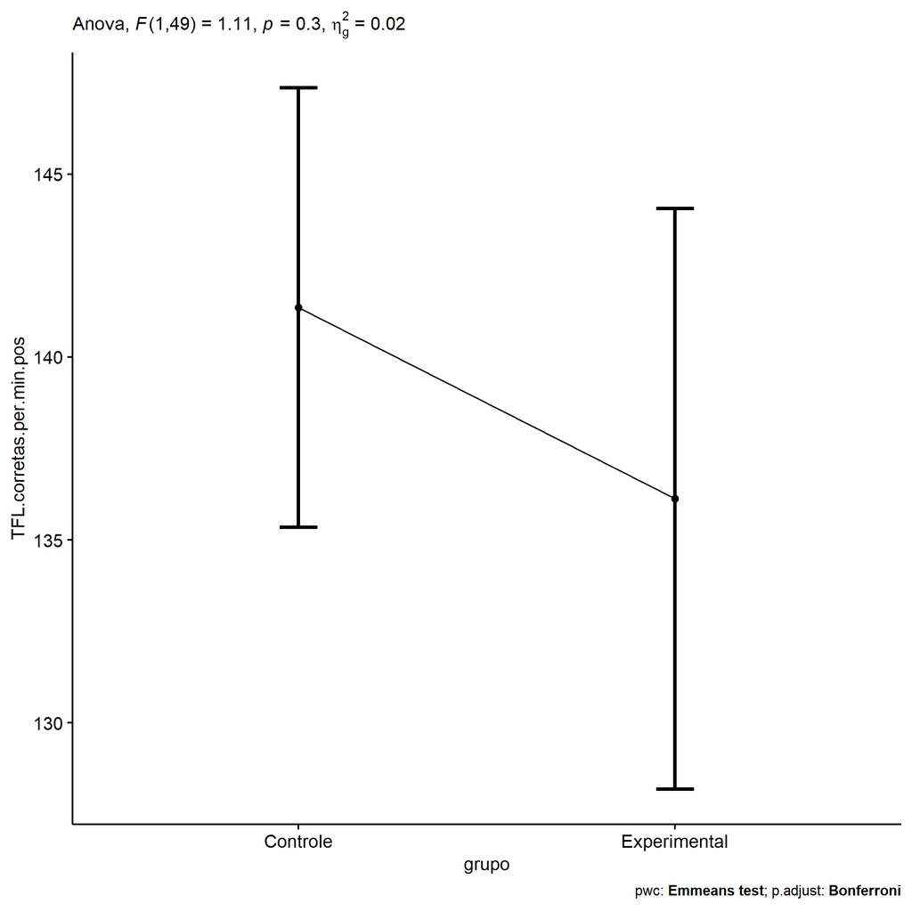

```r
if (!is.null(nrow(plots[["grupo"]]$data)))
  plots[["grupo"]] + ggplot2::scale_color_manual(values = color[["grupo"]])
```

```r
plots <- oneWayAncovaBoxPlots(
  wdat, "TFL.corretas.per.min.pos", "grupo", aov, pwc, covar = "TFL.corretas.per.min.pre",
  theme = "classic", color = color[["grupo"]],
  subtitle = which(aov$Effect == "grupo"))
```

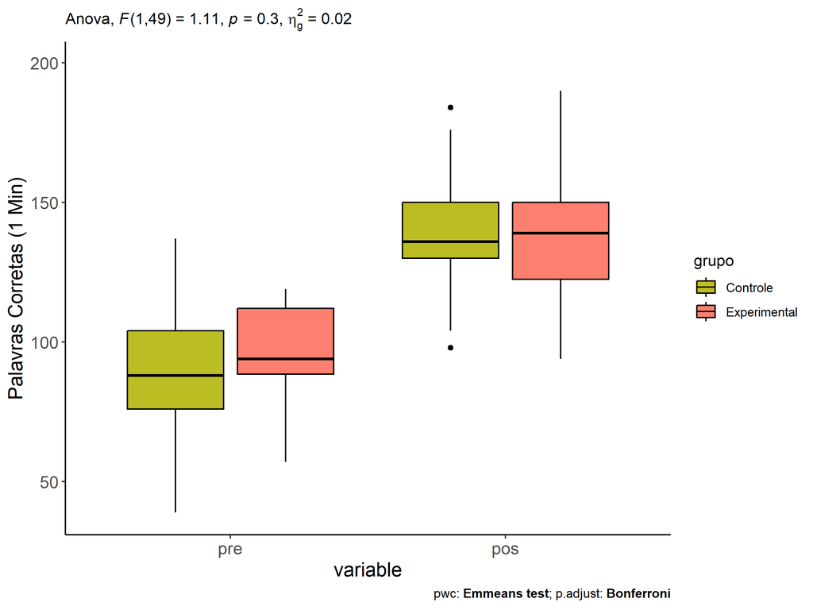

```r
if (length(unique(wdat[["grupo"]])) > 1)
  plots[["grupo"]] + ggplot2::ylab("Palavras Corretas (1 Min)") + ggplot2::scale_x_discrete(labels=c('pre', 'pos'))
```

```r
if (length(unique(wdat.long[["grupo"]])) > 1)
  plots <- oneWayAncovaBoxPlots(
    wdat.long, "TFL.corretas.per.min", "grupo", aov, pwc.long, pre.post = "time",
    theme = "classic", color = color$prepost)
```

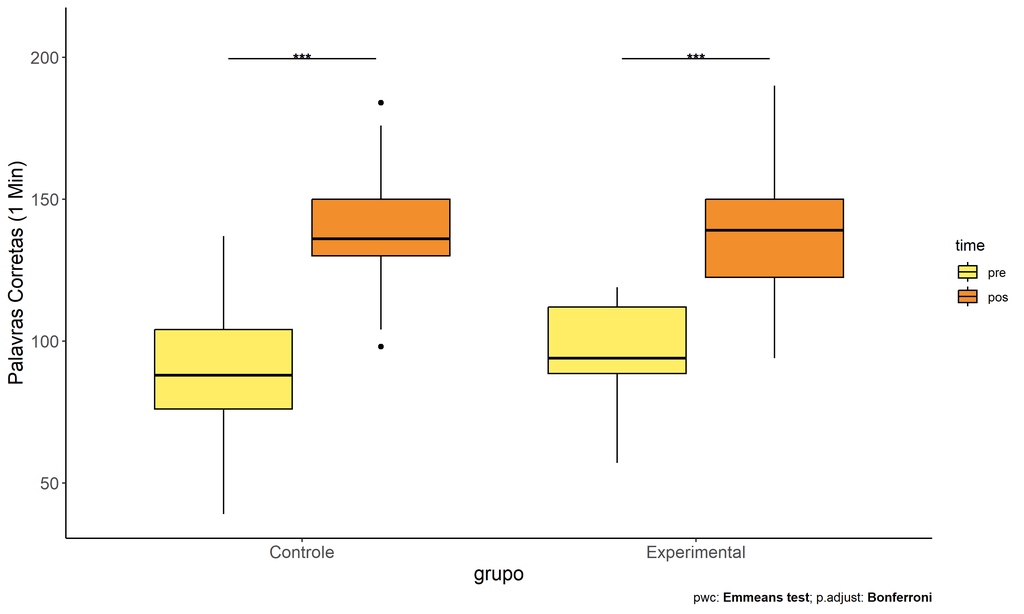

```r
if (length(unique(wdat.long[["grupo"]])) > 1)
  plots[["grupo"]] + ggplot2::ylab("Palavras Corretas (1 Min)")
```

### Checking linearity assumption

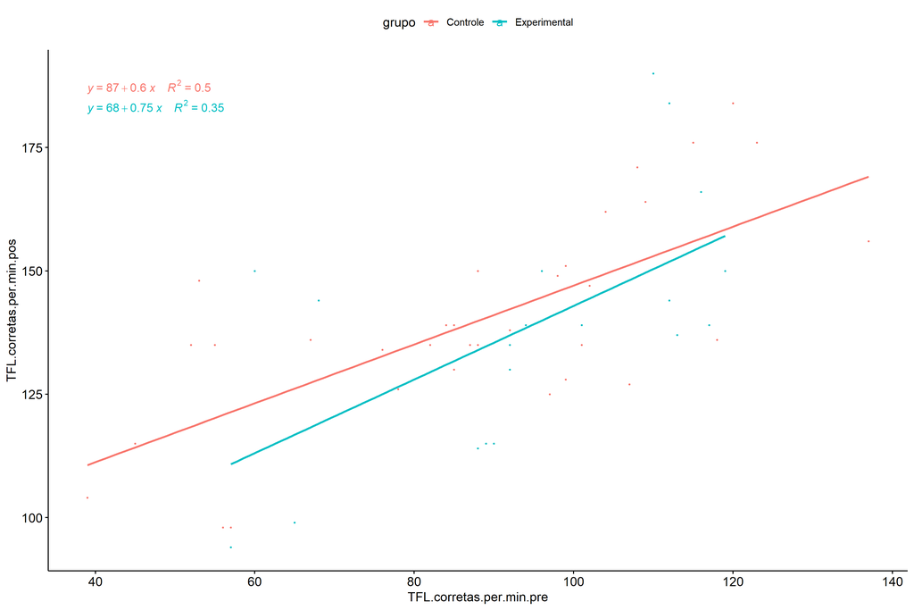

```r
ggscatter(wdat, x = "TFL.corretas.per.min.pre", y = "TFL.corretas.per.min.pos", size = 0.5,
          color = "grupo", add = "reg.line")+
  stat_regline_equation(
    aes(label =  paste(..eq.label.., ..rr.label.., sep = "~~~~"), color = grupo)
  )
```

### Checking normality and homogeneity

```r
res <- augment(lm(TFL.corretas.per.min.pos ~ TFL.corretas.per.min.pre + grupo, data = wdat))
```

```r
shapiro_test(res$.resid)
```

```
## # A tibble: 1 × 3
##   variable   statistic p.value
##   <chr>          <dbl>   <dbl>
## 1 res$.resid     0.955  0.0453
```

```r
levene_test(res, .resid ~ grupo)
```

```
## # A tibble: 1 × 4
##     df1   df2 statistic     p
##   <int> <int>     <dbl> <dbl>
## 1     1    50      1.40 0.242
```

# ANCOVA and Pairwise for two factors **grupo:Sexo**

## Without remove non-normal data

```r
pdat = remove_group_data(dat[!is.na(dat[["grupo"]]) & !is.na(dat[["Sexo"]]),], "TFL.corretas.per.min.pos", c("grupo","Sexo"))

pdat.long <- rbind(pdat[,c("id","grupo","Sexo")], pdat[,c("id","grupo","Sexo")])
pdat.long[["time"]] <- c(rep("pre", nrow(pdat)), rep("pos", nrow(pdat)))
pdat.long[["time"]] <- factor(pdat.long[["time"]], c("pre","pos"))
pdat.long[["TFL.corretas.per.min"]] <- c(pdat[["TFL.corretas.per.min.pre"]], pdat[["TFL.corretas.per.min.pos"]])

aov = anova_test(pdat, TFL.corretas.per.min.pos ~ TFL.corretas.per.min.pre + grupo*Sexo)
laov[["grupo:Sexo"]] <- get_anova_table(aov)
```

```r
pwcs <- list()
pwcs[["Sexo"]] <- emmeans_test(
  group_by(pdat, grupo), TFL.corretas.per.min.pos ~ Sexo,
  covariate = TFL.corretas.per.min.pre, p.adjust.method = "bonferroni")
pwcs[["grupo"]] <- emmeans_test(
  group_by(pdat, Sexo), TFL.corretas.per.min.pos ~ grupo,
  covariate = TFL.corretas.per.min.pre, p.adjust.method = "bonferroni")

pwc <- plyr::rbind.fill(pwcs[["grupo"]], pwcs[["Sexo"]])
pwc <- pwc[,c("grupo","Sexo", colnames(pwc)[!colnames(pwc) %in% c("grupo","Sexo")])]
```

```r
pwc.long <- emmeans_test(dplyr::group_by_at(pdat.long, c("grupo","Sexo")),
                         TFL.corretas.per.min ~ time,
                         p.adjust.method = "bonferroni")
lpwc[["grupo:Sexo"]] <- plyr::rbind.fill(pwc, pwc.long)
```

```r
ds <- get.descriptives(pdat, "TFL.corretas.per.min.pos", c("grupo","Sexo"), covar = "TFL.corretas.per.min.pre")
ds <- merge(ds[ds$variable != "TFL.corretas.per.min.pre",],
            ds[ds$variable == "TFL.corretas.per.min.pre", !colnames(ds) %in% c("variable")],
            by = c("grupo","Sexo"), all.x = T, suffixes = c("", ".TFL.corretas.per.min.pre"))
ds <- merge(get_emmeans(pwcs[["grupo"]]), ds, by = c("grupo","Sexo"), suffixes = c(".emms", ""))
ds <- ds[,c("grupo","Sexo","n","mean.TFL.corretas.per.min.pre","se.TFL.corretas.per.min.pre","mean","se","emmean","se.emms")]

colnames(ds) <- c("grupo","Sexo", "N", paste0(c("M","SE")," (pre)"),
                  paste0(c("M","SE"), " (unadj)"), paste0(c("M", "SE"), " (adj)"))

lemms[["grupo:Sexo"]] <- ds
```

## Computing ANCOVA and PairWise After removing non-normal data (OK)

```r
wdat = pdat

res = residuals(lm(TFL.corretas.per.min.pos ~ TFL.corretas.per.min.pre + grupo*Sexo, data = wdat))
non.normal = getNonNormal(res, wdat$id, plimit = 0.05)

wdat = wdat[!wdat$id %in% non.normal,]

wdat.long <- rbind(wdat[,c("id","grupo","Sexo")], wdat[,c("id","grupo","Sexo")])
wdat.long[["time"]] <- c(rep("pre", nrow(wdat)), rep("pos", nrow(wdat)))
wdat.long[["time"]] <- factor(wdat.long[["time"]], c("pre","pos"))
wdat.long[["TFL.corretas.per.min"]] <- c(wdat[["TFL.corretas.per.min.pre"]], wdat[["TFL.corretas.per.min.pos"]])


ldat[["grupo:Sexo"]] = wdat

(non.normal)
```

```
##  [1] "P463"  "P121"  "P1010" "P2250" "P945"  "P2378" "P808"  "P956"  "P2294" "P2220" "P1768" "P2380" "P446"
## [14] "P3492" "P3721" "P510"  "P2385" "P3729" "P3498" "P133"  "P3516" "P1743" "P623"  "P2211" "P3609" "P128"
## [27] "P445"  "P2377" "P2390" "P2408" "P3504" "P3512" "P2209" "P1698" "P2247" "P2404" "P3521" "P1089" "P2240"
## [40] "P2222" "P3505" "P2214" "P3524" "P1109" "P521"  "P465"  "P3558" "P3581" "P942"  "P3501" "P621"  "P628"
## [53] "P1728" "P820"  "P994"  "P947"  "P184"  "P3566" "P3627" "P1713" "P1017" "P816"  "P2383" "P2401" "P1762"
## [66] "P2376" "P1097" "P3615" "P3630" "P3495" "P1699" "P2244" "P448"  "P241"  "P1716" "P615"  "P3511" "P1091"
## [79] "P950"  "P460"  "P1022" "P2402" "P1764" "P941"
```

```r
aov = anova_test(wdat, TFL.corretas.per.min.pos ~ TFL.corretas.per.min.pre + grupo*Sexo)
laov[["grupo:Sexo"]] <- merge(get_anova_table(aov), laov[["grupo:Sexo"]], by="Effect", suffixes = c("","'"))

(df = get_anova_table(aov))
```

```
## ANOVA Table (type II tests)
##
##                     Effect DFn DFd       F        p p<.05      ges
## 1 TFL.corretas.per.min.pre   1  54 216.425 1.55e-20     * 0.800000
## 2                    grupo   1  54   0.018 8.93e-01       0.000335
## 3                     Sexo   1  54  26.602 3.66e-06     * 0.330000
## 4               grupo:Sexo   1  54   3.690 6.00e-02       0.064000
```

| Effect | DFn | DFd | F | p | p<.05 | ges |
| --- | --- | --- | --- | --- | --- | --- |
| TFL.corretas.per.min.pre | 1 | 54 | 216.425 | 0.000 | * | 0.800 |
| grupo | 1 | 54 | 0.018 | 0.893 |  | 0.000 |
| Sexo | 1 | 54 | 26.602 | 0.000 | * | 0.330 |
| grupo:Sexo | 1 | 54 | 3.690 | 0.060 |  | 0.064 |

```r
pwcs <- list()
pwcs[["Sexo"]] <- emmeans_test(
  group_by(wdat, grupo), TFL.corretas.per.min.pos ~ Sexo,
  covariate = TFL.corretas.per.min.pre, p.adjust.method = "bonferroni")
pwcs[["grupo"]] <- emmeans_test(
  group_by(wdat, Sexo), TFL.corretas.per.min.pos ~ grupo,
  covariate = TFL.corretas.per.min.pre, p.adjust.method = "bonferroni")

pwc <- plyr::rbind.fill(pwcs[["grupo"]], pwcs[["Sexo"]])
pwc <- pwc[,c("grupo","Sexo", colnames(pwc)[!colnames(pwc) %in% c("grupo","Sexo")])]
```

| grupo | Sexo | term | .y. | group1 | group2 | df | statistic | p | p.adj | p.adj.signif |
| --- | --- | --- | --- | --- | --- | --- | --- | --- | --- | --- |
|  | F | TFL.corretas.per.min.pre*grupo | TFL.corretas.per.min.pos | Controle | Experimental | 54 | -1.620 | 0.111 | 0.111 | ns |
|  | M | TFL.corretas.per.min.pre*grupo | TFL.corretas.per.min.pos | Controle | Experimental | 54 | 1.078 | 0.286 | 0.286 | ns |
| Controle |  | TFL.corretas.per.min.pre*Sexo | TFL.corretas.per.min.pos | F | M | 54 | 2.633 | 0.011 | 0.011 | * |
| Experimental |  | TFL.corretas.per.min.pre*Sexo | TFL.corretas.per.min.pos | F | M | 54 | 4.769 | 0.000 | 0.000 | **** |

```r
pwc.long <- emmeans_test(dplyr::group_by_at(wdat.long, c("grupo","Sexo")),
                         TFL.corretas.per.min ~ time,
                         p.adjust.method = "bonferroni")
lpwc[["grupo:Sexo"]] <- merge(plyr::rbind.fill(pwc, pwc.long), lpwc[["grupo:Sexo"]], by=c("grupo","Sexo","term",".y.","group1","group2"), suffixes = c("","'"))
```

| grupo | Sexo | term | .y. | group1 | group2 | df | statistic | p | p.adj | p.adj.signif |
| --- | --- | --- | --- | --- | --- | --- | --- | --- | --- | --- |
| Controle | F | time | TFL.corretas.per.min | pre | pos | 110 | -3.380 | 0.001 | 0.001 | ** |
| Controle | M | time | TFL.corretas.per.min | pre | pos | 110 | -1.983 | 0.050 | 0.050 | * |
| Experimental | F | time | TFL.corretas.per.min | pre | pos | 110 | -2.442 | 0.016 | 0.016 | * |
| Experimental | M | time | TFL.corretas.per.min | pre | pos | 110 | -2.231 | 0.028 | 0.028 | * |

```r
ds <- get.descriptives(wdat, "TFL.corretas.per.min.pos", c("grupo","Sexo"), covar = "TFL.corretas.per.min.pre")
ds <- merge(ds[ds$variable != "TFL.corretas.per.min.pre",],
            ds[ds$variable == "TFL.corretas.per.min.pre", !colnames(ds) %in% c("variable")],
            by = c("grupo","Sexo"), all.x = T, suffixes = c("", ".TFL.corretas.per.min.pre"))
ds <- merge(get_emmeans(pwcs[["grupo"]]), ds, by = c("grupo","Sexo"), suffixes = c(".emms", ""))
ds <- ds[,c("grupo","Sexo","n","mean.TFL.corretas.per.min.pre","se.TFL.corretas.per.min.pre","mean","se","emmean","se.emms")]

colnames(ds) <- c("grupo","Sexo", "N", paste0(c("M","SE")," (pre)"),
                  paste0(c("M","SE"), " (unadj)"), paste0(c("M", "SE"), " (adj)"))

lemms[["grupo:Sexo"]] <- merge(ds, lemms[["grupo:Sexo"]], by=c("grupo","Sexo"), suffixes = c("","'"))
```

| grupo | Sexo | N | M (pre) | SE (pre) | M (unadj) | SE (unadj) | M (adj) | SE (adj) |
| --- | --- | --- | --- | --- | --- | --- | --- | --- |
| Controle | F | 15 | 86.600 | 7.768 | 112.000 | 4.136 | 115.427 | 1.877 |
| Controle | M | 17 | 97.706 | 5.989 | 111.706 | 4.312 | 108.597 | 1.762 |
| Experimental | F | 8 | 99.875 | 4.879 | 125.000 | 5.155 | 120.615 | 2.568 |
| Experimental | M | 19 | 89.158 | 5.059 | 104.053 | 3.391 | 105.975 | 1.660 |

### Plots for ancova

```r
plots <- twoWayAncovaPlots(
  wdat, "TFL.corretas.per.min.pos", c("grupo","Sexo"), aov, pwcs, addParam = c("mean_se"),
  font.label.size=10, step.increase=0.05, p.label="p.adj",
  subtitle = which(aov$Effect == "grupo:Sexo"))
```

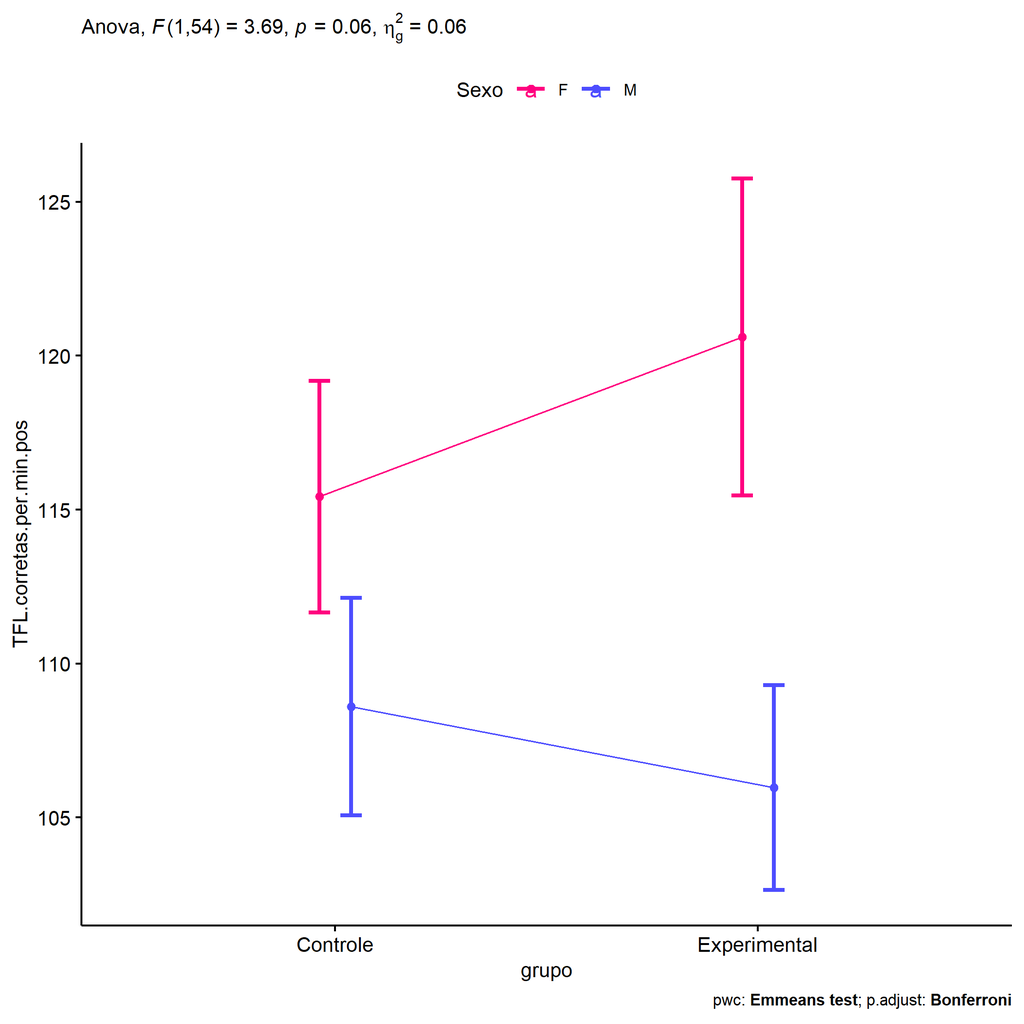

```r
if (!is.null(plots[["grupo"]]))
  plots[["grupo"]] + ggplot2::scale_color_manual(values = color[["Sexo"]])
```

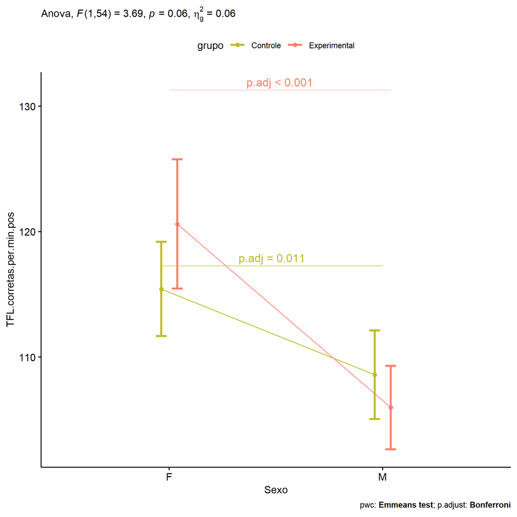

```r
if (!is.null(plots[["Sexo"]]))
  plots[["Sexo"]] + ggplot2::scale_color_manual(values = color[["grupo"]])
```

```r
plots <- twoWayAncovaBoxPlots(
  wdat, "TFL.corretas.per.min.pos", c("grupo","Sexo"), aov, pwcs, covar = "TFL.corretas.per.min.pre",
  theme = "classic", color = color[["grupo:Sexo"]],
  subtitle = which(aov$Effect == "grupo:Sexo"))
```

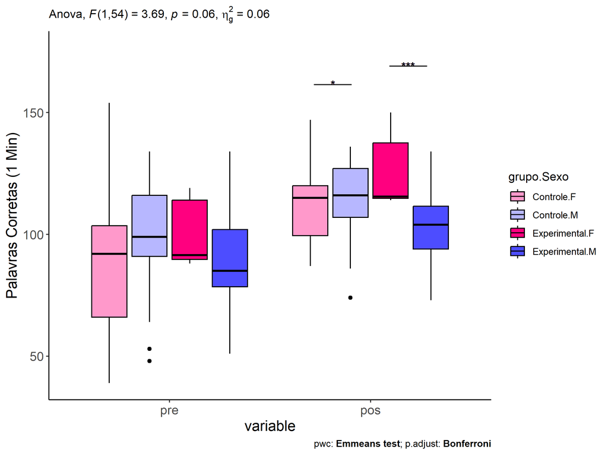

```r
plots[["grupo:Sexo"]] + ggplot2::ylab("Palavras Corretas (1 Min)") + ggplot2::scale_x_discrete(labels=c('pre', 'pos'))
```

```r
plots <- twoWayAncovaBoxPlots(
  wdat.long, "TFL.corretas.per.min", c("grupo","Sexo"), aov, pwc.long, pre.post = "time",
  theme = "classic", color = color$prepost)
```

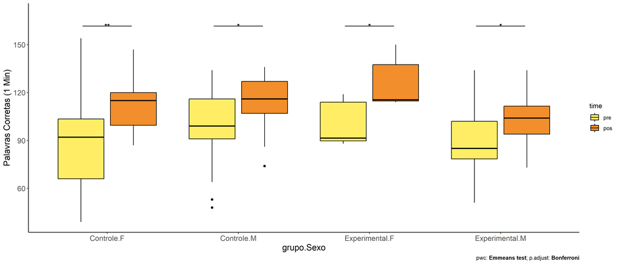

```r
plots[["grupo:Sexo"]] + ggplot2::ylab("Palavras Corretas (1 Min)")
```

### Checking linearity assumption

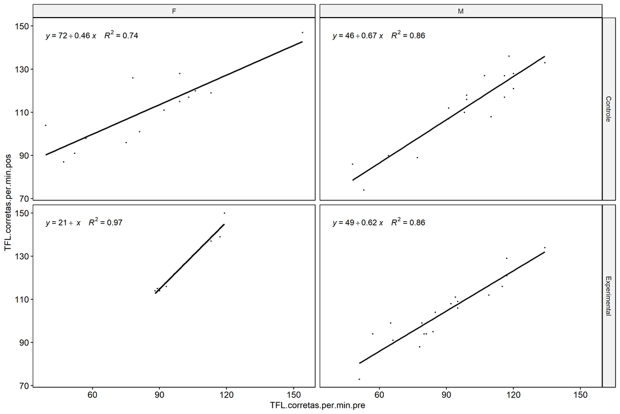

```r
ggscatter(wdat, x = "TFL.corretas.per.min.pre", y = "TFL.corretas.per.min.pos", size = 0.5,
          facet.by = c("grupo","Sexo"), add = "reg.line")+
  stat_regline_equation(
    aes(label =  paste(..eq.label.., ..rr.label.., sep = "~~~~"))
  )
```

### Checking normality and homogeneity

```r
res <- augment(lm(TFL.corretas.per.min.pos ~ TFL.corretas.per.min.pre + grupo*Sexo, data = wdat))
```

```r
shapiro_test(res$.resid)
```

```
## # A tibble: 1 × 3
##   variable   statistic p.value
##   <chr>          <dbl>   <dbl>
## 1 res$.resid     0.951  0.0190
```

```r
levene_test(res, .resid ~ grupo*Sexo)
```

```
## # A tibble: 1 × 4
##     df1   df2 statistic     p
##   <int> <int>     <dbl> <dbl>
## 1     3    55     0.316 0.814
```

# ANCOVA and Pairwise for two factors **grupo:Zona**

## Without remove non-normal data

```r
pdat = remove_group_data(dat[!is.na(dat[["grupo"]]) & !is.na(dat[["Zona"]]),], "TFL.corretas.per.min.pos", c("grupo","Zona"))

pdat.long <- rbind(pdat[,c("id","grupo","Zona")], pdat[,c("id","grupo","Zona")])
pdat.long[["time"]] <- c(rep("pre", nrow(pdat)), rep("pos", nrow(pdat)))
pdat.long[["time"]] <- factor(pdat.long[["time"]], c("pre","pos"))
pdat.long[["TFL.corretas.per.min"]] <- c(pdat[["TFL.corretas.per.min.pre"]], pdat[["TFL.corretas.per.min.pos"]])

aov = anova_test(pdat, TFL.corretas.per.min.pos ~ TFL.corretas.per.min.pre + grupo*Zona)
laov[["grupo:Zona"]] <- get_anova_table(aov)
```

```r
pwcs <- list()
pwcs[["Zona"]] <- emmeans_test(
  group_by(pdat, grupo), TFL.corretas.per.min.pos ~ Zona,
  covariate = TFL.corretas.per.min.pre, p.adjust.method = "bonferroni")
pwcs[["grupo"]] <- emmeans_test(
  group_by(pdat, Zona), TFL.corretas.per.min.pos ~ grupo,
  covariate = TFL.corretas.per.min.pre, p.adjust.method = "bonferroni")

pwc <- plyr::rbind.fill(pwcs[["grupo"]], pwcs[["Zona"]])
pwc <- pwc[,c("grupo","Zona", colnames(pwc)[!colnames(pwc) %in% c("grupo","Zona")])]
```

```r
pwc.long <- emmeans_test(dplyr::group_by_at(pdat.long, c("grupo","Zona")),
                         TFL.corretas.per.min ~ time,
                         p.adjust.method = "bonferroni")
lpwc[["grupo:Zona"]] <- plyr::rbind.fill(pwc, pwc.long)
```

```r
ds <- get.descriptives(pdat, "TFL.corretas.per.min.pos", c("grupo","Zona"), covar = "TFL.corretas.per.min.pre")
ds <- merge(ds[ds$variable != "TFL.corretas.per.min.pre",],
            ds[ds$variable == "TFL.corretas.per.min.pre", !colnames(ds) %in% c("variable")],
            by = c("grupo","Zona"), all.x = T, suffixes = c("", ".TFL.corretas.per.min.pre"))
ds <- merge(get_emmeans(pwcs[["grupo"]]), ds, by = c("grupo","Zona"), suffixes = c(".emms", ""))
ds <- ds[,c("grupo","Zona","n","mean.TFL.corretas.per.min.pre","se.TFL.corretas.per.min.pre","mean","se","emmean","se.emms")]

colnames(ds) <- c("grupo","Zona", "N", paste0(c("M","SE")," (pre)"),
                  paste0(c("M","SE"), " (unadj)"), paste0(c("M", "SE"), " (adj)"))

lemms[["grupo:Zona"]] <- ds
```

## Computing ANCOVA and PairWise After removing non-normal data (OK)

```r
wdat = pdat

res = residuals(lm(TFL.corretas.per.min.pos ~ TFL.corretas.per.min.pre + grupo*Zona, data = wdat))
non.normal = getNonNormal(res, wdat$id, plimit = 0.05)

wdat = wdat[!wdat$id %in% non.normal,]

wdat.long <- rbind(wdat[,c("id","grupo","Zona")], wdat[,c("id","grupo","Zona")])
wdat.long[["time"]] <- c(rep("pre", nrow(wdat)), rep("pos", nrow(wdat)))
wdat.long[["time"]] <- factor(wdat.long[["time"]], c("pre","pos"))
wdat.long[["TFL.corretas.per.min"]] <- c(wdat[["TFL.corretas.per.min.pre"]], wdat[["TFL.corretas.per.min.pos"]])


ldat[["grupo:Zona"]] = wdat

(non.normal)
```

```
## [1] "P510"  "P1768" "P1743" "P2378" "P945"  "P1698" "P2220"
```

```r
aov = anova_test(wdat, TFL.corretas.per.min.pos ~ TFL.corretas.per.min.pre + grupo*Zona)
laov[["grupo:Zona"]] <- merge(get_anova_table(aov), laov[["grupo:Zona"]], by="Effect", suffixes = c("","'"))

(df = get_anova_table(aov))
```

```
## ANOVA Table (type II tests)
##
##                     Effect DFn DFd      F        p p<.05      ges
## 1 TFL.corretas.per.min.pre   1  94 76.601 8.25e-14     * 0.449000
## 2                    grupo   1  94  0.011 9.18e-01       0.000114
## 3                     Zona   1  94 42.906 3.03e-09     * 0.313000
## 4               grupo:Zona   1  94  3.994 4.90e-02     * 0.041000
```

| Effect | DFn | DFd | F | p | p<.05 | ges |
| --- | --- | --- | --- | --- | --- | --- |
| TFL.corretas.per.min.pre | 1 | 94 | 76.601 | 0.000 | * | 0.449 |
| grupo | 1 | 94 | 0.011 | 0.918 |  | 0.000 |
| Zona | 1 | 94 | 42.906 | 0.000 | * | 0.313 |
| grupo:Zona | 1 | 94 | 3.994 | 0.049 | * | 0.041 |

```r
pwcs <- list()
pwcs[["Zona"]] <- emmeans_test(
  group_by(wdat, grupo), TFL.corretas.per.min.pos ~ Zona,
  covariate = TFL.corretas.per.min.pre, p.adjust.method = "bonferroni")
pwcs[["grupo"]] <- emmeans_test(
  group_by(wdat, Zona), TFL.corretas.per.min.pos ~ grupo,
  covariate = TFL.corretas.per.min.pre, p.adjust.method = "bonferroni")

pwc <- plyr::rbind.fill(pwcs[["grupo"]], pwcs[["Zona"]])
pwc <- pwc[,c("grupo","Zona", colnames(pwc)[!colnames(pwc) %in% c("grupo","Zona")])]
```

| grupo | Zona | term | .y. | group1 | group2 | df | statistic | p | p.adj | p.adj.signif |
| --- | --- | --- | --- | --- | --- | --- | --- | --- | --- | --- |
|  | Rural | TFL.corretas.per.min.pre*grupo | TFL.corretas.per.min.pos | Controle | Experimental | 94 | -0.841 | 0.403 | 0.403 | ns |
|  | Urbana | TFL.corretas.per.min.pre*grupo | TFL.corretas.per.min.pos | Controle | Experimental | 94 | 1.817 | 0.072 | 0.072 | ns |
| Controle |  | TFL.corretas.per.min.pre*Zona | TFL.corretas.per.min.pos | Rural | Urbana | 94 | -6.213 | 0.000 | 0.000 | **** |
| Experimental |  | TFL.corretas.per.min.pre*Zona | TFL.corretas.per.min.pos | Rural | Urbana | 94 | -2.890 | 0.005 | 0.005 | ** |

```r
pwc.long <- emmeans_test(dplyr::group_by_at(wdat.long, c("grupo","Zona")),
                         TFL.corretas.per.min ~ time,
                         p.adjust.method = "bonferroni")
lpwc[["grupo:Zona"]] <- merge(plyr::rbind.fill(pwc, pwc.long), lpwc[["grupo:Zona"]], by=c("grupo","Zona","term",".y.","group1","group2"), suffixes = c("","'"))
```

| grupo | Zona | term | .y. | group1 | group2 | df | statistic | p | p.adj | p.adj.signif |
| --- | --- | --- | --- | --- | --- | --- | --- | --- | --- | --- |
| Controle | Rural | time | TFL.corretas.per.min | pre | pos | 190 | -2.328 | 0.021 | 0.021 | * |
| Controle | Urbana | time | TFL.corretas.per.min | pre | pos | 190 | -4.142 | 0.000 | 0.000 | **** |
| Experimental | Rural | time | TFL.corretas.per.min | pre | pos | 190 | -2.406 | 0.017 | 0.017 | * |
| Experimental | Urbana | time | TFL.corretas.per.min | pre | pos | 190 | -2.294 | 0.023 | 0.023 | * |

```r
ds <- get.descriptives(wdat, "TFL.corretas.per.min.pos", c("grupo","Zona"), covar = "TFL.corretas.per.min.pre")
ds <- merge(ds[ds$variable != "TFL.corretas.per.min.pre",],
            ds[ds$variable == "TFL.corretas.per.min.pre", !colnames(ds) %in% c("variable")],
            by = c("grupo","Zona"), all.x = T, suffixes = c("", ".TFL.corretas.per.min.pre"))
ds <- merge(get_emmeans(pwcs[["grupo"]]), ds, by = c("grupo","Zona"), suffixes = c(".emms", ""))
ds <- ds[,c("grupo","Zona","n","mean.TFL.corretas.per.min.pre","se.TFL.corretas.per.min.pre","mean","se","emmean","se.emms")]

colnames(ds) <- c("grupo","Zona", "N", paste0(c("M","SE")," (pre)"),
                  paste0(c("M","SE"), " (unadj)"), paste0(c("M", "SE"), " (adj)"))

lemms[["grupo:Zona"]] <- merge(ds, lemms[["grupo:Zona"]], by=c("grupo","Zona"), suffixes = c("","'"))
```

| grupo | Zona | N | M (pre) | SE (pre) | M (unadj) | SE (unadj) | M (adj) | SE (adj) |
| --- | --- | --- | --- | --- | --- | --- | --- | --- |
| Controle | Rural | 54 | 91.111 | 3.608 | 101.259 | 2.955 | 101.490 | 2.205 |
| Controle | Urbana | 7 | 92.286 | 9.097 | 142.429 | 10.792 | 141.934 | 6.124 |
| Experimental | Rural | 32 | 89.969 | 3.268 | 103.594 | 3.038 | 104.530 | 2.866 |
| Experimental | Urbana | 6 | 102.000 | 6.713 | 132.000 | 13.849 | 125.503 | 6.656 |

### Plots for ancova

```r
plots <- twoWayAncovaPlots(
  wdat, "TFL.corretas.per.min.pos", c("grupo","Zona"), aov, pwcs, addParam = c("mean_se"),
  font.label.size=10, step.increase=0.05, p.label="p.adj",
  subtitle = which(aov$Effect == "grupo:Zona"))
```

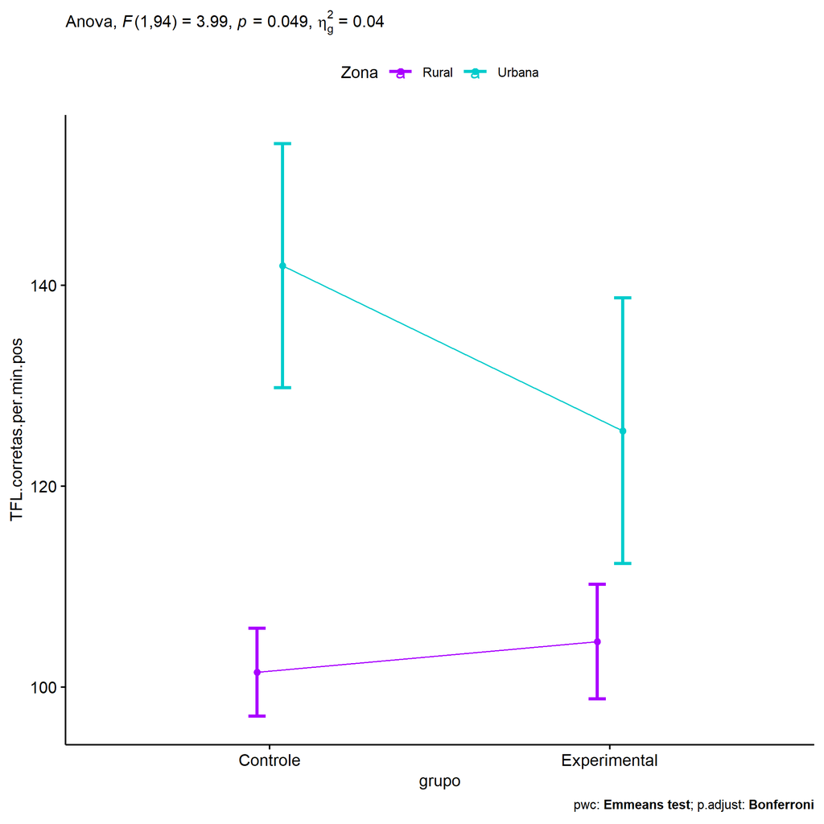

```r
if (!is.null(plots[["grupo"]]))
  plots[["grupo"]] + ggplot2::scale_color_manual(values = color[["Zona"]])
```

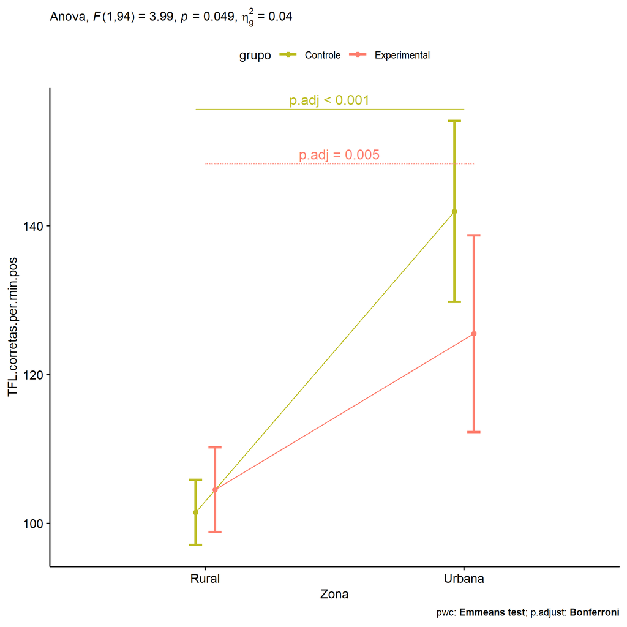

```r
if (!is.null(plots[["Zona"]]))
  plots[["Zona"]] + ggplot2::scale_color_manual(values = color[["grupo"]])
```

```r
plots <- twoWayAncovaBoxPlots(
  wdat, "TFL.corretas.per.min.pos", c("grupo","Zona"), aov, pwcs, covar = "TFL.corretas.per.min.pre",
  theme = "classic", color = color[["grupo:Zona"]],
  subtitle = which(aov$Effect == "grupo:Zona"))
```

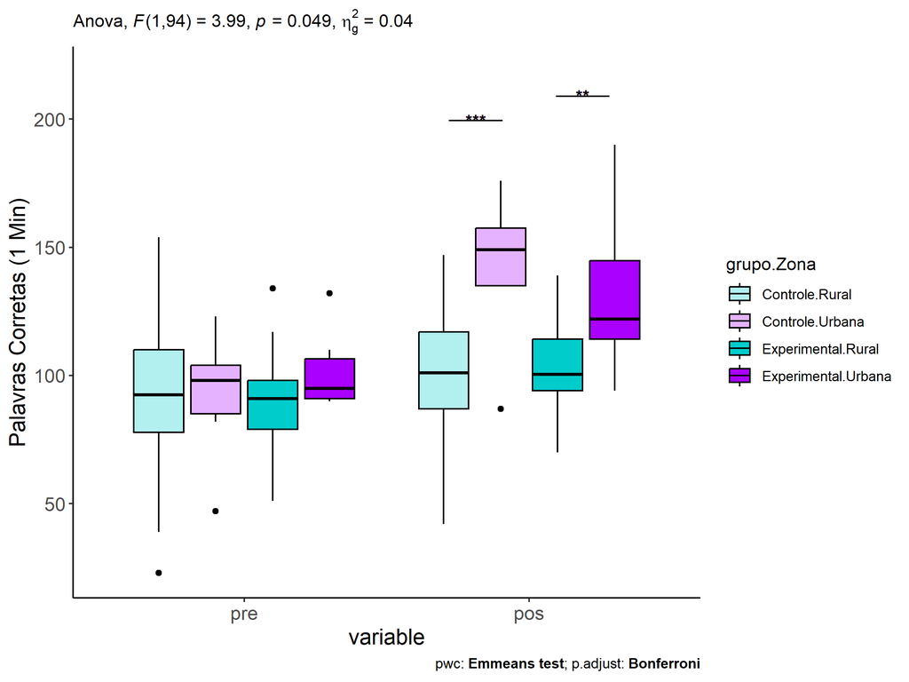

```r
plots[["grupo:Zona"]] + ggplot2::ylab("Palavras Corretas (1 Min)") + ggplot2::scale_x_discrete(labels=c('pre', 'pos'))
```

```r
plots <- twoWayAncovaBoxPlots(
  wdat.long, "TFL.corretas.per.min", c("grupo","Zona"), aov, pwc.long, pre.post = "time",
  theme = "classic", color = color$prepost)
```

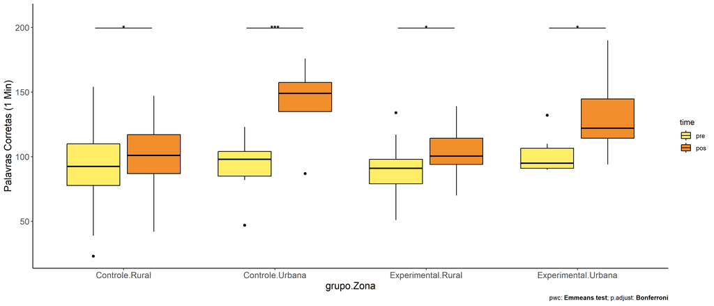

```r
plots[["grupo:Zona"]] + ggplot2::ylab("Palavras Corretas (1 Min)")
```

### Checking linearity assumption

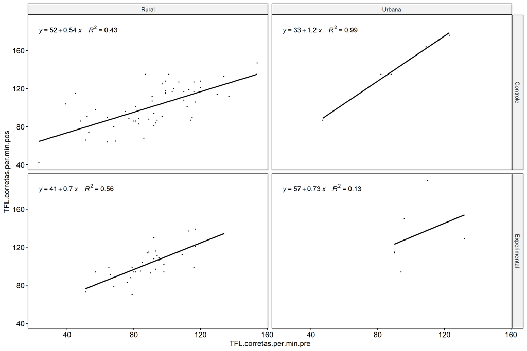

```r
ggscatter(wdat, x = "TFL.corretas.per.min.pre", y = "TFL.corretas.per.min.pos", size = 0.5,
          facet.by = c("grupo","Zona"), add = "reg.line")+
  stat_regline_equation(
    aes(label =  paste(..eq.label.., ..rr.label.., sep = "~~~~"))
  )
```

### Checking normality and homogeneity

```r
res <- augment(lm(TFL.corretas.per.min.pos ~ TFL.corretas.per.min.pre + grupo*Zona, data = wdat))
```

```r
shapiro_test(res$.resid)
```

```
## # A tibble: 1 × 3
##   variable   statistic p.value
##   <chr>          <dbl>   <dbl>
## 1 res$.resid     0.980   0.133
```

```r
levene_test(res, .resid ~ grupo*Zona)
```

```
## # A tibble: 1 × 4
##     df1   df2 statistic      p
##   <int> <int>     <dbl>  <dbl>
## 1     3    95      3.55 0.0173
```

# ANCOVA and Pairwise for two factors **grupo:Cor.Raca**

## Without remove non-normal data

```r
pdat = remove_group_data(dat[!is.na(dat[["grupo"]]) & !is.na(dat[["Cor.Raca"]]),], "TFL.corretas.per.min.pos", c("grupo","Cor.Raca"))
pdat.long <- rbind(pdat[,c("id","grupo","Cor.Raca")], pdat[,c("id","grupo","Cor.Raca")])
pdat.long[["time"]] <- c(rep("pre", nrow(pdat)), rep("pos", nrow(pdat)))
pdat.long[["time"]] <- factor(pdat.long[["time"]], c("pre","pos"))
pdat.long[["TFL.corretas.per.min"]] <- c(pdat[["TFL.corretas.per.min.pre"]], pdat[["TFL.corretas.per.min.pos"]])

aov = anova_test(pdat, TFL.corretas.per.min.pos ~ TFL.corretas.per.min.pre + grupo*Cor.Raca)
laov[["grupo:Cor.Raca"]] <- get_anova_table(aov)
```

```r
pwcs <- list()
pwcs[["Cor.Raca"]] <- emmeans_test(
  group_by(pdat, grupo), TFL.corretas.per.min.pos ~ Cor.Raca,
  covariate = TFL.corretas.per.min.pre, p.adjust.method = "bonferroni")
pwcs[["grupo"]] <- emmeans_test(
  group_by(pdat, Cor.Raca), TFL.corretas.per.min.pos ~ grupo,
  covariate = TFL.corretas.per.min.pre, p.adjust.method = "bonferroni")

pwc <- plyr::rbind.fill(pwcs[["grupo"]], pwcs[["Cor.Raca"]])
pwc <- pwc[,c("grupo","Cor.Raca", colnames(pwc)[!colnames(pwc) %in% c("grupo","Cor.Raca")])]
```

```r
pwc.long <- emmeans_test(dplyr::group_by_at(pdat.long, c("grupo","Cor.Raca")),
                         TFL.corretas.per.min ~ time,
                         p.adjust.method = "bonferroni")
lpwc[["grupo:Cor.Raca"]] <- plyr::rbind.fill(pwc, pwc.long)
```

```r
ds <- get.descriptives(pdat, "TFL.corretas.per.min.pos", c("grupo","Cor.Raca"), covar = "TFL.corretas.per.min.pre")
ds <- merge(ds[ds$variable != "TFL.corretas.per.min.pre",],
            ds[ds$variable == "TFL.corretas.per.min.pre", !colnames(ds) %in% c("variable")],
            by = c("grupo","Cor.Raca"), all.x = T, suffixes = c("", ".TFL.corretas.per.min.pre"))
ds <- merge(get_emmeans(pwcs[["grupo"]]), ds, by = c("grupo","Cor.Raca"), suffixes = c(".emms", ""))
ds <- ds[,c("grupo","Cor.Raca","n","mean.TFL.corretas.per.min.pre","se.TFL.corretas.per.min.pre","mean","se","emmean","se.emms")]

colnames(ds) <- c("grupo","Cor.Raca", "N", paste0(c("M","SE")," (pre)"),
                  paste0(c("M","SE"), " (unadj)"), paste0(c("M", "SE"), " (adj)"))

lemms[["grupo:Cor.Raca"]] <- ds
```

## Computing ANCOVA and PairWise After removing non-normal data (OK)

```r
wdat = pdat

res = residuals(lm(TFL.corretas.per.min.pos ~ TFL.corretas.per.min.pre + grupo*Cor.Raca, data = wdat))
non.normal = getNonNormal(res, wdat$id, plimit = 0.05)

wdat = wdat[!wdat$id %in% non.normal,]

wdat.long <- rbind(wdat[,c("id","grupo","Cor.Raca")], wdat[,c("id","grupo","Cor.Raca")])
wdat.long[["time"]] <- c(rep("pre", nrow(wdat)), rep("pos", nrow(wdat)))
wdat.long[["time"]] <- factor(wdat.long[["time"]], c("pre","pos"))
wdat.long[["TFL.corretas.per.min"]] <- c(wdat[["TFL.corretas.per.min.pre"]], wdat[["TFL.corretas.per.min.pos"]])


ldat[["grupo:Cor.Raca"]] = wdat

(non.normal)
```

```
## [1] "P510"  "P1728" "P623"
```

```r
aov = anova_test(wdat, TFL.corretas.per.min.pos ~ TFL.corretas.per.min.pre + grupo*Cor.Raca)
laov[["grupo:Cor.Raca"]] <- merge(get_anova_table(aov), laov[["grupo:Cor.Raca"]], by="Effect", suffixes = c("","'"))

(df = get_anova_table(aov))
```

```
## ANOVA Table (type II tests)
##
##                     Effect DFn DFd      F        p p<.05   ges
## 1 TFL.corretas.per.min.pre   1  73 72.878 1.38e-12     * 0.500
## 2                    grupo   1  73  3.851 5.40e-02       0.050
## 3                 Cor.Raca   2  73  3.425 3.80e-02     * 0.086
## 4           grupo:Cor.Raca   1  73  0.372 5.44e-01       0.005
```

| Effect | DFn | DFd | F | p | p<.05 | ges |
| --- | --- | --- | --- | --- | --- | --- |
| TFL.corretas.per.min.pre | 1 | 73 | 72.878 | 0.000 | * | 0.500 |
| grupo | 1 | 73 | 3.851 | 0.054 |  | 0.050 |
| Cor.Raca | 2 | 73 | 3.425 | 0.038 | * | 0.086 |
| grupo:Cor.Raca | 1 | 73 | 0.372 | 0.544 |  | 0.005 |

```r
pwcs <- list()
pwcs[["Cor.Raca"]] <- emmeans_test(
  group_by(wdat, grupo), TFL.corretas.per.min.pos ~ Cor.Raca,
  covariate = TFL.corretas.per.min.pre, p.adjust.method = "bonferroni")
pwcs[["grupo"]] <- emmeans_test(
  group_by(wdat, Cor.Raca), TFL.corretas.per.min.pos ~ grupo,
  covariate = TFL.corretas.per.min.pre, p.adjust.method = "bonferroni")

pwc <- plyr::rbind.fill(pwcs[["grupo"]], pwcs[["Cor.Raca"]])
pwc <- pwc[,c("grupo","Cor.Raca", colnames(pwc)[!colnames(pwc) %in% c("grupo","Cor.Raca")])]
```

| grupo | Cor.Raca | term | .y. | group1 | group2 | df | statistic | p | p.adj | p.adj.signif |
| --- | --- | --- | --- | --- | --- | --- | --- | --- | --- | --- |
|  | Branca | TFL.corretas.per.min.pre*grupo | TFL.corretas.per.min.pos | Controle | Experimental | 73 | -1.492 | 0.140 | 0.140 | ns |
|  | Indígena | TFL.corretas.per.min.pre*grupo | TFL.corretas.per.min.pos | Controle | Experimental |  |  |  |  |  |
|  | Parda | TFL.corretas.per.min.pre*grupo | TFL.corretas.per.min.pos | Controle | Experimental | 73 | -1.413 | 0.162 | 0.162 | ns |
| Controle |  | TFL.corretas.per.min.pre*Cor.Raca | TFL.corretas.per.min.pos | Branca | Indígena |  |  |  |  |  |
| Controle |  | TFL.corretas.per.min.pre*Cor.Raca | TFL.corretas.per.min.pos | Branca | Parda | 73 | 1.903 | 0.061 | 0.061 | ns |
| Controle |  | TFL.corretas.per.min.pre*Cor.Raca | TFL.corretas.per.min.pos | Indígena | Parda |  |  |  |  |  |
| Experimental |  | TFL.corretas.per.min.pre*Cor.Raca | TFL.corretas.per.min.pos | Branca | Indígena | 73 | 1.472 | 0.145 | 0.436 | ns |
| Experimental |  | TFL.corretas.per.min.pre*Cor.Raca | TFL.corretas.per.min.pos | Branca | Parda | 73 | 1.954 | 0.055 | 0.164 | ns |
| Experimental |  | TFL.corretas.per.min.pre*Cor.Raca | TFL.corretas.per.min.pos | Indígena | Parda | 73 | 0.397 | 0.692 | 1.000 | ns |

```r
pwc.long <- emmeans_test(dplyr::group_by_at(wdat.long, c("grupo","Cor.Raca")),
                         TFL.corretas.per.min ~ time,
                         p.adjust.method = "bonferroni")
lpwc[["grupo:Cor.Raca"]] <- merge(plyr::rbind.fill(pwc, pwc.long), lpwc[["grupo:Cor.Raca"]], by=c("grupo","Cor.Raca","term",".y.","group1","group2"), suffixes = c("","'"))
```

| grupo | Cor.Raca | term | .y. | group1 | group2 | df | statistic | p | p.adj | p.adj.signif |
| --- | --- | --- | --- | --- | --- | --- | --- | --- | --- | --- |
| Controle | Branca | time | TFL.corretas.per.min | pre | pos | 148 | -1.211 | 0.228 | 0.228 | ns |
| Controle | Indígena | time | TFL.corretas.per.min | pre | pos |  |  |  |  |  |
| Controle | Parda | time | TFL.corretas.per.min | pre | pos | 148 | -1.048 | 0.296 | 0.296 | ns |
| Experimental | Branca | time | TFL.corretas.per.min | pre | pos | 148 | -1.665 | 0.098 | 0.098 | ns |
| Experimental | Indígena | time | TFL.corretas.per.min | pre | pos | 148 | -1.256 | 0.211 | 0.211 | ns |
| Experimental | Parda | time | TFL.corretas.per.min | pre | pos | 148 | -1.684 | 0.094 | 0.094 | ns |

```r
ds <- get.descriptives(wdat, "TFL.corretas.per.min.pos", c("grupo","Cor.Raca"), covar = "TFL.corretas.per.min.pre")
ds <- merge(ds[ds$variable != "TFL.corretas.per.min.pre",],
            ds[ds$variable == "TFL.corretas.per.min.pre", !colnames(ds) %in% c("variable")],
            by = c("grupo","Cor.Raca"), all.x = T, suffixes = c("", ".TFL.corretas.per.min.pre"))
ds <- merge(get_emmeans(pwcs[["grupo"]]), ds, by = c("grupo","Cor.Raca"), suffixes = c(".emms", ""))
ds <- ds[,c("grupo","Cor.Raca","n","mean.TFL.corretas.per.min.pre","se.TFL.corretas.per.min.pre","mean","se","emmean","se.emms")]

colnames(ds) <- c("grupo","Cor.Raca", "N", paste0(c("M","SE")," (pre)"),
                  paste0(c("M","SE"), " (unadj)"), paste0(c("M", "SE"), " (adj)"))

lemms[["grupo:Cor.Raca"]] <- merge(ds, lemms[["grupo:Cor.Raca"]], by=c("grupo","Cor.Raca"), suffixes = c("","'"))
```

| grupo | Cor.Raca | N | M (pre) | SE (pre) | M (unadj) | SE (unadj) | M (adj) | SE (adj) |
| --- | --- | --- | --- | --- | --- | --- | --- | --- |
| Controle | Branca | 12 | 103.667 | 4.606 | 114.000 | 5.510 | 106.812 | 4.292 |
| Controle | Parda | 38 | 90.974 | 3.848 | 96.000 | 3.471 | 97.427 | 2.371 |
| Experimental | Branca | 5 | 103.400 | 5.591 | 125.400 | 8.310 | 118.393 | 6.571 |
| Experimental | Indígena | 8 | 92.750 | 7.260 | 105.875 | 7.492 | 106.096 | 5.154 |
| Experimental | Parda | 16 | 87.062 | 5.173 | 99.500 | 4.798 | 103.581 | 3.676 |